# POLS 3604

Lecture 13 | Policy Making in the House and Senate

## Plan for Today

- Discuss the floor process in the Senate

## Senate Process

- The Senate is considered an individual body
- Very autonomous body that has the ability to deliberate and compromise
- But if the Senate constantly had to give way to each member, then nothing would get accomplished

## UCAs in the Senate

- Unanimous Consent Agreements
  - Allow the Senate to avoid chamber rules that would bog down the process
  - Structure debate, amendments, and timing of the vote
    - Similar to special rules in the House
    - Difference is that every senator must agree to it
  - Negotiated between the majority and minority party leadership (and some other members like committee members or partisan leaders)

## Germaneness in the Senate

- The Senate has no rules relating to the germaneness of a bill/topic
- Senators can offer practically any amendment to a bill being considered on the floor
  - Assuming it adheres to the UCA

## Withholding Consent

- In recent years, we have seen an increase in members not agreeing to UCAs, thereby threatening to extend debate on a bill
- Filibuster
  - Is any tactic that blocks a measure on the Senate floor from coming to a vote
    - Generally, in the form of a single lawmaker refusing to end debate by making a long uninterrupted speech
- How are filibusters possible?
  - Chamber rules require the presiding officer to recognize all senators wishing to speak
  - The Senate lacks any formal provision regarding time limits on debate
- How is a filibuster conducted
  - Once recognized, the senator may speak at length, without yielding the floor, but must remain standing and speaking
  - Senate procedure prohibits members from yielding the floor to other members
    - Questions from other senators is not prohibited
      - Therefore, a colleague can help a filibustering member by asking a very long question
- Longest individual filibuster: Strom Thurmond (D-SC) 24 hours and 18 minutes
  - Filibuster the Civil Rights Act of 1957
  - Started speaking at 8:54pm on August 28 and continued until 9:12pm the following day
    - Recited the Declaration of Independence, Bill of Rights, Washington’s Farewell Address and other historical documents
    - Failed to prevent passage of the bill
- Holds
  - A more informal version of a filibuster
    - Informal in that it is not specified in the chamber rules
  - A hold registers a senator’s intention to object to any UCA
  - Called a silent filibuster
  - Usually for less salient legislation

## Cloture

- How do we stop/avoid a filibuster?
- Invoke Cloture
  - Limits debate to 30 hours
  - 3/5s of the members are required (60)
- Established in 1971
  - Originally, needed 2/3s of members (67)
- Generally, required members from both parties
  - Exception was in 1975 and 1978 (Democrats)

## Amendments in the Senate

- Once a bill reaches the Senate floor it is open to amendments at any time
  - Assuming it is within the UCA
- Types of amendments in the Senate
  - First-Degree Amendment
    - Changing the text of the bill
  - Second-Degree Amendment
    - Changing the text of an amendment
  - Striking language from the bill
  - Inserting new language into a bill
  - Replacing the entire bill with new language
- The amendment tree

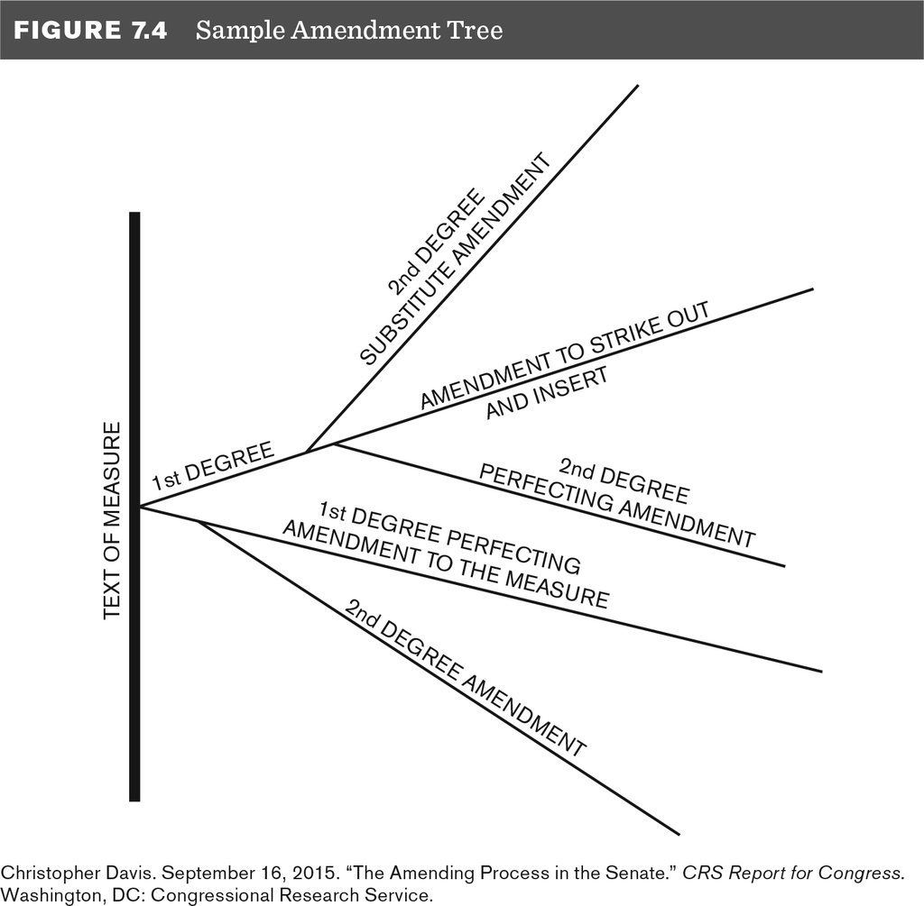

- The amendment tree, by nature of being recognized first, is controlled by the majority party leader
  - Therefore, the majority party leader can effectively control what (and who) is introduced as amendments

## Final Thoughts

- The legislative process is a long and arduous task

## What Do You Need to Do For Next Class?

- Exam 1
- Read TUSC Chapter 8 (Two weeks from now)
- Congressional Simulation - Committee Meeting I (Two weeks from now)